# Predict Bike Sharing Demand with AutoGluon Template

## Project: Predict Bike Sharing Demand with AutoGluon

This notebook is a template with each step that you need to complete for the project.

Please fill in your code where there are explicit `?` markers in the notebook. You are welcome to add more cells and code as you see fit.

Once you have completed all the code implementations, please export your notebook as a HTML file so the reviews can view your code. Make sure you have all outputs correctly outputted.

`File-> Export Notebook As... -> Export Notebook as HTML`

There is a writeup to complete as well after all code implememtation is done. Please answer all questions and attach the necessary tables and charts. You can complete the writeup in either markdown or PDF.

Completing the code template and writeup template will cover all of the rubric points for this project.

The rubric contains "Stand Out Suggestions" for enhancing the project beyond the minimum requirements. The stand out suggestions are optional. If you decide to pursue the "stand out suggestions", you can include the code in this notebook and also discuss the results in the writeup file.

## Step 1: Create an account with Kaggle

### Create Kaggle Account and download API key

Below is example of steps to get the API username and key. Each student will have their own username and key.

1. Open account settings.
2. Scroll down to API and click Create New API Token.
3. Open up `kaggle.json` and use the username and key.

## Step 2: Download the Kaggle dataset using the kaggle python library

### Open up Sagemaker Studio and use starter template

1. Notebook should be using a `ml.t3.medium` instance (2 vCPU + 4 GiB)
2. Notebook should be using kernal: `Python 3 (MXNet 1.8 Python 3.7 CPU Optimized)`

### Install packages

```python
!pip install -U pip
!pip install -U setuptools wheel
!pip install -U "mxnet<2.0.0" bokeh==2.0.1
!pip install autogluon --no-cache-dir
```

[output not shown]

[output cut: 121 more lines]

[output not shown]

### Setup Kaggle API Key

```python
!pip install -q Kaggle

!mkdir -p /root/.kaggle
!touch /root/.kaggle/kaggle.json
!chmod 600 /root/.kaggle/kaggle.json

!kaggle competitions download -c bike-sharing-demand
!unzip -o bike-sharing-demand.zip
```

```
WARNING: Running pip as the 'root' user can result in broken permissions and conflicting behaviour with the system package manager. It is recommended to use a virtual environment instead: https://pip.pypa.io/warnings/venv
bike-sharing-demand.zip: Skipping, found more recently modified local copy (use --force to force download)
Archive:  bike-sharing-demand.zip
  inflating: sampleSubmission.csv
  inflating: test.csv
  inflating: train.csv
```

### Download and explore dataset

```python
import json
import pandas as pd

import matplotlib.pyplot as plt
import autogluon.core as ag

from autogluon.tabular import TabularPredictor
```

```python
kaggle_username = "siddp6"
kaggle_key = "2e5f7520d0f1ef3e8e133d6b1241caf9"

with open("/root/.kaggle/kaggle.json", "w") as f:
    f.write(json.dumps({"username": kaggle_username, "key": kaggle_key}))
```

### Go to the [bike sharing demand competition](https://www.kaggle.com/c/bike-sharing-demand) and agree to the terms

```python
train = pd.read_csv("train.csv",parse_dates=["datetime"])
train.head()
```

|  | datetime | season | holiday | workingday | weather | temp | atemp | humidity | windspeed | casual | registered | count |
| --- | --- | --- | --- | --- | --- | --- | --- | --- | --- | --- | --- | --- |
| 0 | 2011-01-01 00:00:00 | 1 | 0 | 0 | 1 | 9.84 | 14.395 | 81 | 0.0 | 3 | 13 | 16 |
| 1 | 2011-01-01 01:00:00 | 1 | 0 | 0 | 1 | 9.02 | 13.635 | 80 | 0.0 | 8 | 32 | 40 |
| 2 | 2011-01-01 02:00:00 | 1 | 0 | 0 | 1 | 9.02 | 13.635 | 80 | 0.0 | 5 | 27 | 32 |
| 3 | 2011-01-01 03:00:00 | 1 | 0 | 0 | 1 | 9.84 | 14.395 | 75 | 0.0 | 3 | 10 | 13 |
| 4 | 2011-01-01 04:00:00 | 1 | 0 | 0 | 1 | 9.84 | 14.395 | 75 | 0.0 | 0 | 1 | 1 |

```python
train.describe()
```

|  | season | holiday | workingday | weather | temp | atemp | humidity | windspeed | casual | registered | count |
| --- | --- | --- | --- | --- | --- | --- | --- | --- | --- | --- | --- |
| count | 10886.000000 | 10886.000000 | 10886.000000 | 10886.000000 | 10886.00000 | 10886.000000 | 10886.000000 | 10886.000000 | 10886.000000 | 10886.000000 | 10886.000000 |
| mean | 2.506614 | 0.028569 | 0.680875 | 1.418427 | 20.23086 | 23.655084 | 61.886460 | 12.799395 | 36.021955 | 155.552177 | 191.574132 |
| std | 1.116174 | 0.166599 | 0.466159 | 0.633839 | 7.79159 | 8.474601 | 19.245033 | 8.164537 | 49.960477 | 151.039033 | 181.144454 |
| min | 1.000000 | 0.000000 | 0.000000 | 1.000000 | 0.82000 | 0.760000 | 0.000000 | 0.000000 | 0.000000 | 0.000000 | 1.000000 |
| 25% | 2.000000 | 0.000000 | 0.000000 | 1.000000 | 13.94000 | 16.665000 | 47.000000 | 7.001500 | 4.000000 | 36.000000 | 42.000000 |
| 50% | 3.000000 | 0.000000 | 1.000000 | 1.000000 | 20.50000 | 24.240000 | 62.000000 | 12.998000 | 17.000000 | 118.000000 | 145.000000 |
| 75% | 4.000000 | 0.000000 | 1.000000 | 2.000000 | 26.24000 | 31.060000 | 77.000000 | 16.997900 | 49.000000 | 222.000000 | 284.000000 |
| max | 4.000000 | 1.000000 | 1.000000 | 4.000000 | 41.00000 | 45.455000 | 100.000000 | 56.996900 | 367.000000 | 886.000000 | 977.000000 |

```python
train.info()
```

```
<class 'pandas.core.frame.DataFrame'>
RangeIndex: 10886 entries, 0 to 10885
Data columns (total 12 columns):
 #   Column      Non-Null Count  Dtype
---  ------      --------------  -----
 0   datetime    10886 non-null  datetime64[ns]
 1   season      10886 non-null  int64
 2   holiday     10886 non-null  int64
 3   workingday  10886 non-null  int64
 4   weather     10886 non-null  int64
 5   temp        10886 non-null  float64
 6   atemp       10886 non-null  float64
 7   humidity    10886 non-null  int64
 8   windspeed   10886 non-null  float64
 9   casual      10886 non-null  int64
 10  registered  10886 non-null  int64
 11  count       10886 non-null  int64
dtypes: datetime64[ns](1), float64(3), int64(8)
memory usage: 1020.7 KB
```

```python
test = pd.read_csv("test.csv",parse_dates=["datetime"])
test.head()
```

|  | datetime | season | holiday | workingday | weather | temp | atemp | humidity | windspeed |
| --- | --- | --- | --- | --- | --- | --- | --- | --- | --- |
| 0 | 2011-01-20 00:00:00 | 1 | 0 | 1 | 1 | 10.66 | 11.365 | 56 | 26.0027 |
| 1 | 2011-01-20 01:00:00 | 1 | 0 | 1 | 1 | 10.66 | 13.635 | 56 | 0.0000 |
| 2 | 2011-01-20 02:00:00 | 1 | 0 | 1 | 1 | 10.66 | 13.635 | 56 | 0.0000 |
| 3 | 2011-01-20 03:00:00 | 1 | 0 | 1 | 1 | 10.66 | 12.880 | 56 | 11.0014 |
| 4 | 2011-01-20 04:00:00 | 1 | 0 | 1 | 1 | 10.66 | 12.880 | 56 | 11.0014 |

```python
submission = pd.read_csv("sampleSubmission.csv",parse_dates=["datetime"])
submission.head()
```

|  | datetime | count |
| --- | --- | --- |
| 0 | 2011-01-20 00:00:00 | 0 |
| 1 | 2011-01-20 01:00:00 | 0 |
| 2 | 2011-01-20 02:00:00 | 0 |
| 3 | 2011-01-20 03:00:00 | 0 |
| 4 | 2011-01-20 04:00:00 | 0 |

## Step 3: Train a model using AutoGluon’s Tabular Prediction

Requirements:

```python
predictor = TabularPredictor(
    label="count",
    problem_type="regression",
    eval_metric="root_mean_squared_error",
    learner_kwargs={"ignored_columns": ["casual", "registered"]},
)
```

```
No path specified. Models will be saved in: "AutogluonModels/ag-20230601_143631/"
```

```python
predictor.fit(train_data=train, time_limit=120, presets="best_quality")
```

```
Presets specified: ['best_quality']
Stack configuration (auto_stack=True): num_stack_levels=1, num_bag_folds=8, num_bag_sets=20
Beginning AutoGluon training ... Time limit = 120s
AutoGluon will save models to "AutogluonModels/ag-20230601_143631/"
AutoGluon Version:  0.7.0
Python Version:     3.8.10
Operating System:   Linux
Platform Machine:   x86_64
Platform Version:   #1 SMP Tue Apr 25 15:24:19 UTC 2023
Train Data Rows:    10886
Train Data Columns: 11
Label Column: count
Preprocessing data ...
Using Feature Generators to preprocess the data ...
Dropping user-specified ignored columns: ['casual', 'registered']
Fitting AutoMLPipelineFeatureGenerator...
	Available Memory:                    3058.78 MB
	Train Data (Original)  Memory Usage: 0.78 MB (0.0% of available memory)
	Inferring data type of each feature based on column values. Set feature_metadata_in to manually specify special dtypes of the features.
	Stage 1 Generators:
		Fitting AsTypeFeatureGenerator...
			Note: Converting 2 features to boolean dtype as they only contain 2 unique values.
	Stage 2 Generators:
		Fitting FillNaFeatureGenerator...
	Stage 3 Generators:
		Fitting IdentityFeatureGenerator...
		Fitting DatetimeFeatureGenerator...
	Stage 4 Generators:
		Fitting DropUniqueFeatureGenerator...
	Types of features in original data (raw dtype, special dtypes):
		('datetime', []) : 1 | ['datetime']
		('float', [])    : 3 | ['temp', 'atemp', 'windspeed']
		('int', [])      : 5 | ['season', 'holiday', 'workingday', 'weather', 'humidity']
	Types of features in processed data (raw dtype, special dtypes):
		('float', [])                : 3 | ['temp', 'atemp', 'windspeed']
		('int', [])                  : 3 | ['season', 'weather', 'humidity']
		('int', ['bool'])            : 2 | ['holiday', 'workingday']
		('int', ['datetime_as_int']) : 5 | ['datetime', 'datetime.year', 'datetime.month', 'datetime.day', 'datetime.dayofweek']
	0.1s = Fit runtime
	9 features in original data used to generate 13 features in processed data.
```

[output cut: 28 more lines]

```
	0.26s	 = Training   runtime
	0.0s	 = Validation runtime
Fitting 9 L2 models ...
Fitting model: LightGBMXT_BAG_L2 ... Training model for up to 23.2s of the 23.19s of remaining time.
	Fitting 8 child models (S1F1 - S1F8) | Fitting with ParallelLocalFoldFittingStrategy
	-61.1166	 = Validation score   (-root_mean_squared_error)
	36.24s	 = Training   runtime
	3.18s	 = Validation runtime
Completed 1/20 k-fold bagging repeats ...
Fitting model: WeightedEnsemble_L3 ... Training model for up to 119.88s of the -17.5s of remaining time.
	-61.1166	 = Validation score   (-root_mean_squared_error)
	0.01s	 = Training   runtime
	0.0s	 = Validation runtime
AutoGluon training complete, total runtime = 137.71s ... Best model: "WeightedEnsemble_L3"
TabularPredictor saved. To load, use: predictor = TabularPredictor.load("AutogluonModels/ag-20230601_143631/")
```

```
<autogluon.tabular.predictor.predictor.TabularPredictor at 0x7fe07cbc6dc0>
```

### Review AutoGluon's training run with ranking of models that did the best.

```python
predictor.fit_summary()
```

```
*** Summary of fit() ***
Estimated performance of each model:
                   model   score_val  pred_time_val    fit_time  pred_time_val_marginal  fit_time_marginal  stack_level  can_infer  fit_order
0      LightGBMXT_BAG_L2  -61.116628      14.533524  116.015757                3.184328          36.244766            2       True          6
1    WeightedEnsemble_L3  -61.116628      14.534755  116.020841                0.001231           0.005084            3       True          7
2  KNeighborsDist_BAG_L1  -84.125061       0.038734    0.029795                0.038734           0.029795            1       True          2
3    WeightedEnsemble_L2  -84.125061       0.039469    0.285632                0.000736           0.255837            2       True          5
4  KNeighborsUnif_BAG_L1 -101.546199       0.045319    0.040213                0.045319           0.040213            1       True          1
5        LightGBM_BAG_L1 -131.077080       1.415203   21.460628                1.415203          21.460628            1       True          4
6      LightGBMXT_BAG_L1 -131.460909       9.849940   58.240355                9.849940          58.240355            1       True          3
Number of models trained: 7
Types of models trained:
{'WeightedEnsembleModel', 'StackerEnsembleModel_LGB', 'StackerEnsembleModel_KNN'}
Bagging used: True  (with 8 folds)
Multi-layer stack-ensembling used: True  (with 3 levels)
Feature Metadata (Processed):
(raw dtype, special dtypes):
('float', [])                : 3 | ['temp', 'atemp', 'windspeed']
('int', [])                  : 3 | ['season', 'weather', 'humidity']
('int', ['bool'])            : 2 | ['holiday', 'workingday']
('int', ['datetime_as_int']) : 5 | ['datetime', 'datetime.year', 'datetime.month', 'datetime.day', 'datetime.dayofweek']
Plot summary of models saved to file: AutogluonModels/ag-20230601_143631/SummaryOfModels.html
*** End of fit() summary ***
```

[output not shown]

[output cut: 39 more lines]

```
 1                0.001231           0.005084            3       True
 2                0.038734           0.029795            1       True
 3                0.000736           0.255837            2       True
 4                0.045319           0.040213            1       True
 5                1.415203          21.460628            1       True
 6                9.849940          58.240355            1       True

    fit_order
 0          6
 1          7
 2          2
 3          5
 4          1
 5          4
 6          3  }
```

```
                   model   score_val  pred_time_val    fit_time  pred_time_val_marginal  fit_time_marginal  stack_level  can_infer  fit_order
0      LightGBMXT_BAG_L2  -61.116628      14.533524  116.015757                3.184328          36.244766            2       True          6
1    WeightedEnsemble_L3  -61.116628      14.534755  116.020841                0.001231           0.005084            3       True          7
2  KNeighborsDist_BAG_L1  -84.125061       0.038734    0.029795                0.038734           0.029795            1       True          2
3    WeightedEnsemble_L2  -84.125061       0.039469    0.285632                0.000736           0.255837            2       True          5
4  KNeighborsUnif_BAG_L1 -101.546199       0.045319    0.040213                0.045319           0.040213            1       True          1
5        LightGBM_BAG_L1 -131.077080       1.415203   21.460628                1.415203          21.460628            1       True          4
6      LightGBMXT_BAG_L1 -131.460909       9.849940   58.240355                9.849940          58.240355            1       True          3
```

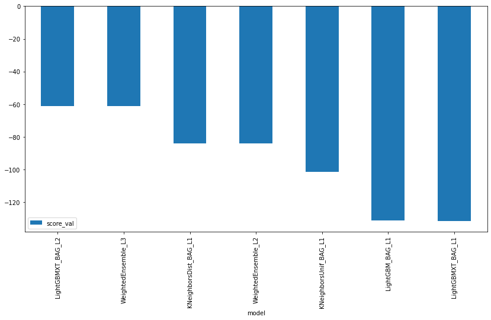

```python
leaderboard_df = pd.DataFrame(predictor.leaderboard())
leaderboard_df.plot(kind="bar", x="model", y="score_val", figsize=(14, 7))
plt.show()
```

### Create predictions from test dataset

```python
predictions = predictor.predict(test)
predictions.head()
```

```
0    36.413548
1    42.656593
2    49.778008
3    52.446659
4    55.068695
Name: count, dtype: float32
```

#### NOTE: Kaggle will reject the submission if we don't set everything to be > 0.

```python
predictions[predictions < 0] = 0
```

### Set predictions to submission dataframe, save, and submit

```python
submission["count"] = predictions
submission.to_csv("submission.csv", index=False)
```

```python
!kaggle competitions submit -c bike-sharing-demand -f submission.csv -m "Initial Submission"
```

```
Successfully submitted to Bike Sharing Demand
```

#### View submission via the command line or in the web browser under the competition's page - `My Submissions`

```python
!kaggle competitions submissions -c bike-sharing-demand | tail -n +1 | head -n 6
```

```
fileName                     date                 description                                                                                         status    publicScore  privateScore
---------------------------  -------------------  --------------------------------------------------------------------------------------------------  --------  -----------  ------------
submission.csv               2023-06-01 14:39:34  Initial Submission                                                                                  pending
submission_new_hyp_3.csv     2023-06-01 07:29:37  new features with hyperparameters epoch, boost round, learning rate, extra trees, drop-out, leaves  complete  0.50079      0.50079
submission_new_hyp_2.csv     2023-06-01 07:29:35  new features with hyperparameters epoch, boost round, learning rate, extra trees                    complete  0.65221      0.65221
submission_new_hyp_1.csv     2023-06-01 07:29:33  new features with hyperparameters epoch, boost round                                                complete  0.60933      0.60933
tail: write error: Broken pipe
```

## Step 4: Exploratory Data Analysis and Creating an additional feature

- Any additional feature will do, but a great suggestion would be to separate out the datetime into hour, day, or month parts.

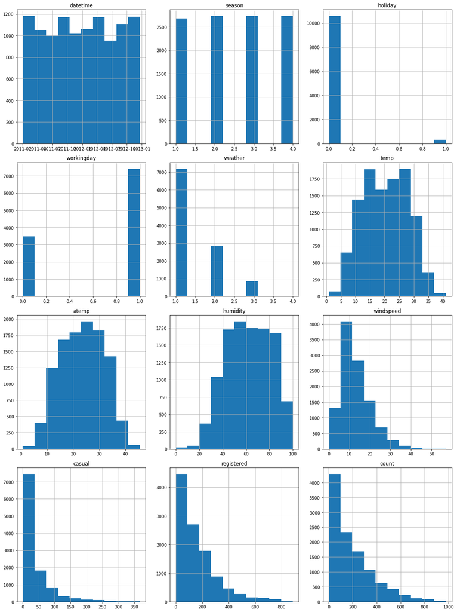

```python
train.hist(figsize=(15,20))
plt.tight_layout()
plt.show()
```

```python
train["hour"] = train["datetime"].dt.hour
train["day"] = train["datetime"].dt.dayofweek
train.drop(["datetime"], axis=1, inplace=True)
train.head()
```

|  | season | holiday | workingday | weather | temp | atemp | humidity | windspeed | casual | registered | count | hour | day |
| --- | --- | --- | --- | --- | --- | --- | --- | --- | --- | --- | --- | --- | --- |
| 0 | 1 | 0 | 0 | 1 | 9.84 | 14.395 | 81 | 0.0 | 3 | 13 | 16 | 0 | 5 |
| 1 | 1 | 0 | 0 | 1 | 9.02 | 13.635 | 80 | 0.0 | 8 | 32 | 40 | 1 | 5 |
| 2 | 1 | 0 | 0 | 1 | 9.02 | 13.635 | 80 | 0.0 | 5 | 27 | 32 | 2 | 5 |
| 3 | 1 | 0 | 0 | 1 | 9.84 | 14.395 | 75 | 0.0 | 3 | 10 | 13 | 3 | 5 |
| 4 | 1 | 0 | 0 | 1 | 9.84 | 14.395 | 75 | 0.0 | 0 | 1 | 1 | 4 | 5 |

```python
test["hour"] = test["datetime"].dt.hour
test["day"] = test["datetime"].dt.dayofweek
test.drop(["datetime"], axis=1, inplace=True)
test.head()
```

|  | season | holiday | workingday | weather | temp | atemp | humidity | windspeed | hour | day |
| --- | --- | --- | --- | --- | --- | --- | --- | --- | --- | --- |
| 0 | 1 | 0 | 1 | 1 | 10.66 | 11.365 | 56 | 26.0027 | 0 | 3 |
| 1 | 1 | 0 | 1 | 1 | 10.66 | 13.635 | 56 | 0.0000 | 1 | 3 |
| 2 | 1 | 0 | 1 | 1 | 10.66 | 13.635 | 56 | 0.0000 | 2 | 3 |
| 3 | 1 | 0 | 1 | 1 | 10.66 | 12.880 | 56 | 11.0014 | 3 | 3 |
| 4 | 1 | 0 | 1 | 1 | 10.66 | 12.880 | 56 | 11.0014 | 4 | 3 |

## Make category types for these so models know they are not just numbers

- AutoGluon originally sees these as ints, but in reality they are int representations of a category.
- Setting the dtype to category will classify these as categories in AutoGluon.

```python
train["season"] = train["season"].astype("category")
train["weather"] = train["weather"].astype("category")

test["season"] = test["season"].astype("category")
test["weather"] = test["weather"].astype("category")
```

```python
train.head()
```

|  | season | holiday | workingday | weather | temp | atemp | humidity | windspeed | casual | registered | count | hour | day |
| --- | --- | --- | --- | --- | --- | --- | --- | --- | --- | --- | --- | --- | --- |
| 0 | 1 | 0 | 0 | 1 | 9.84 | 14.395 | 81 | 0.0 | 3 | 13 | 16 | 0 | 5 |
| 1 | 1 | 0 | 0 | 1 | 9.02 | 13.635 | 80 | 0.0 | 8 | 32 | 40 | 1 | 5 |
| 2 | 1 | 0 | 0 | 1 | 9.02 | 13.635 | 80 | 0.0 | 5 | 27 | 32 | 2 | 5 |
| 3 | 1 | 0 | 0 | 1 | 9.84 | 14.395 | 75 | 0.0 | 3 | 10 | 13 | 3 | 5 |
| 4 | 1 | 0 | 0 | 1 | 9.84 | 14.395 | 75 | 0.0 | 0 | 1 | 1 | 4 | 5 |

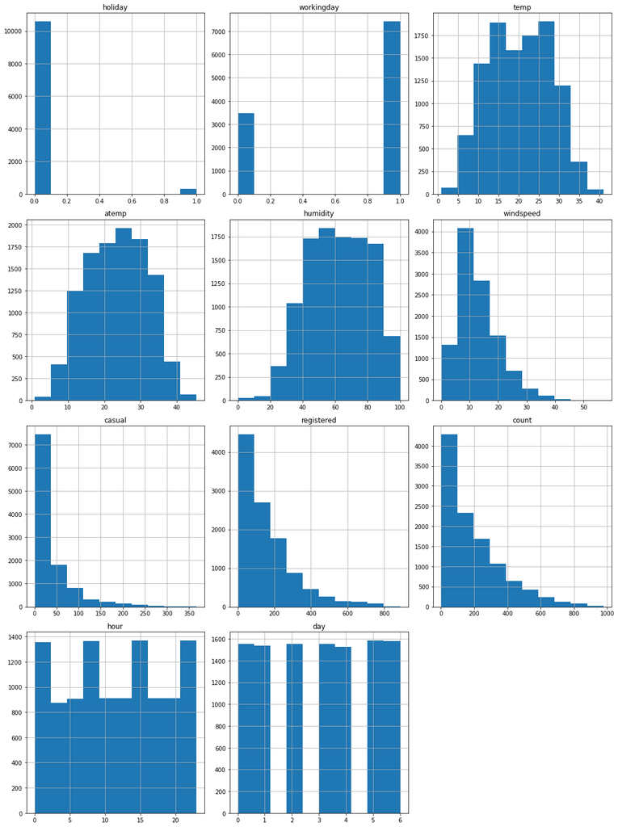

```python
train.hist(figsize=(15, 20))
plt.tight_layout()
plt.show()
```

## Step 5: Rerun the model with the same settings as before, just with more features

```python
predictor_new_features = TabularPredictor(
    label="count",
    problem_type="regression",
    eval_metric="root_mean_squared_error",
    learner_kwargs={"ignored_columns": ["casual", "registered"]},
)
```

```
No path specified. Models will be saved in: "AutogluonModels/ag-20230601_143940/"
```

```python
predictor_new_features.fit(train_data=train, time_limit=120, presets="best_quality")
```

```
Presets specified: ['best_quality']
Stack configuration (auto_stack=True): num_stack_levels=1, num_bag_folds=8, num_bag_sets=20
Beginning AutoGluon training ... Time limit = 120s
AutoGluon will save models to "AutogluonModels/ag-20230601_143940/"
AutoGluon Version:  0.7.0
Python Version:     3.8.10
Operating System:   Linux
Platform Machine:   x86_64
Platform Version:   #1 SMP Tue Apr 25 15:24:19 UTC 2023
Train Data Rows:    10886
Train Data Columns: 12
Label Column: count
Preprocessing data ...
Using Feature Generators to preprocess the data ...
Dropping user-specified ignored columns: ['casual', 'registered']
Fitting AutoMLPipelineFeatureGenerator...
	Available Memory:                    2588.44 MB
	Train Data (Original)  Memory Usage: 0.72 MB (0.0% of available memory)
	Inferring data type of each feature based on column values. Set feature_metadata_in to manually specify special dtypes of the features.
	Stage 1 Generators:
		Fitting AsTypeFeatureGenerator...
			Note: Converting 2 features to boolean dtype as they only contain 2 unique values.
	Stage 2 Generators:
		Fitting FillNaFeatureGenerator...
	Stage 3 Generators:
		Fitting IdentityFeatureGenerator...
		Fitting CategoryFeatureGenerator...
			Fitting CategoryMemoryMinimizeFeatureGenerator...
	Stage 4 Generators:
		Fitting DropUniqueFeatureGenerator...
	Types of features in original data (raw dtype, special dtypes):
		('category', []) : 2 | ['season', 'weather']
		('float', [])    : 3 | ['temp', 'atemp', 'windspeed']
		('int', [])      : 5 | ['holiday', 'workingday', 'humidity', 'hour', 'day']
	Types of features in processed data (raw dtype, special dtypes):
		('category', [])  : 2 | ['season', 'weather']
		('float', [])     : 3 | ['temp', 'atemp', 'windspeed']
		('int', [])       : 3 | ['humidity', 'hour', 'day']
		('int', ['bool']) : 2 | ['holiday', 'workingday']
	0.1s = Fit runtime
```

[output cut: 29 more lines]

```
	-60.9777	 = Validation score   (-root_mean_squared_error)
	16.38s	 = Training   runtime
	0.22s	 = Validation runtime
Fitting model: LightGBM_BAG_L2 ... Training model for up to 4.25s of the 4.24s of remaining time.
	Fitting 8 child models (S1F1 - S1F8) | Fitting with ParallelLocalFoldFittingStrategy
	-60.209	 = Validation score   (-root_mean_squared_error)
	14.98s	 = Training   runtime
	0.11s	 = Validation runtime
Completed 1/20 k-fold bagging repeats ...
Fitting model: WeightedEnsemble_L3 ... Training model for up to 119.9s of the -14.47s of remaining time.
	-59.964	 = Validation score   (-root_mean_squared_error)
	0.16s	 = Training   runtime
	0.0s	 = Validation runtime
AutoGluon training complete, total runtime = 134.81s ... Best model: "WeightedEnsemble_L3"
TabularPredictor saved. To load, use: predictor = TabularPredictor.load("AutogluonModels/ag-20230601_143940/")
```

```
<autogluon.tabular.predictor.predictor.TabularPredictor at 0x7fdf408fd520>
```

```python
predictor_new_features.fit_summary()
```

```
*** Summary of fit() ***
Estimated performance of each model:
                   model   score_val  pred_time_val    fit_time  pred_time_val_marginal  fit_time_marginal  stack_level  can_infer  fit_order
0    WeightedEnsemble_L3  -59.963984      25.299021  120.690456                0.000761           0.163419            3       True          7
1    WeightedEnsemble_L2  -60.125100      24.873514   89.367040                0.000833           0.217180            2       True          4
2      LightGBMXT_BAG_L1  -60.197098      24.770082   89.127638               24.770082          89.127638            1       True          3
3        LightGBM_BAG_L2  -60.209039      25.080539  104.148664                0.114307          14.976510            2       True          6
4      LightGBMXT_BAG_L2  -60.977720      25.183953  105.550528                0.217721          16.378374            2       True          5
5  KNeighborsDist_BAG_L1 -114.004045       0.102599    0.022222                0.102599           0.022222            1       True          2
6  KNeighborsUnif_BAG_L1 -117.060748       0.093551    0.022294                0.093551           0.022294            1       True          1
Number of models trained: 7
Types of models trained:
{'WeightedEnsembleModel', 'StackerEnsembleModel_LGB', 'StackerEnsembleModel_KNN'}
Bagging used: True  (with 8 folds)
Multi-layer stack-ensembling used: True  (with 3 levels)
Feature Metadata (Processed):
(raw dtype, special dtypes):
('category', [])  : 2 | ['season', 'weather']
('float', [])     : 3 | ['temp', 'atemp', 'windspeed']
('int', [])       : 3 | ['humidity', 'hour', 'day']
('int', ['bool']) : 2 | ['holiday', 'workingday']
Plot summary of models saved to file: AutogluonModels/ag-20230601_143940/SummaryOfModels.html
*** End of fit() summary ***
```

[output not shown]

[output cut: 39 more lines]

```
 1                0.000833           0.217180            2       True
 2               24.770082          89.127638            1       True
 3                0.114307          14.976510            2       True
 4                0.217721          16.378374            2       True
 5                0.102599           0.022222            1       True
 6                0.093551           0.022294            1       True

    fit_order
 0          7
 1          4
 2          3
 3          6
 4          5
 5          2
 6          1  }
```

```
                   model   score_val  pred_time_val    fit_time  pred_time_val_marginal  fit_time_marginal  stack_level  can_infer  fit_order
0    WeightedEnsemble_L3  -59.963984      25.299021  120.690456                0.000761           0.163419            3       True          7
1    WeightedEnsemble_L2  -60.125100      24.873514   89.367040                0.000833           0.217180            2       True          4
2      LightGBMXT_BAG_L1  -60.197098      24.770082   89.127638               24.770082          89.127638            1       True          3
3        LightGBM_BAG_L2  -60.209039      25.080539  104.148664                0.114307          14.976510            2       True          6
4      LightGBMXT_BAG_L2  -60.977720      25.183953  105.550528                0.217721          16.378374            2       True          5
5  KNeighborsDist_BAG_L1 -114.004045       0.102599    0.022222                0.102599           0.022222            1       True          2
6  KNeighborsUnif_BAG_L1 -117.060748       0.093551    0.022294                0.093551           0.022294            1       True          1
```

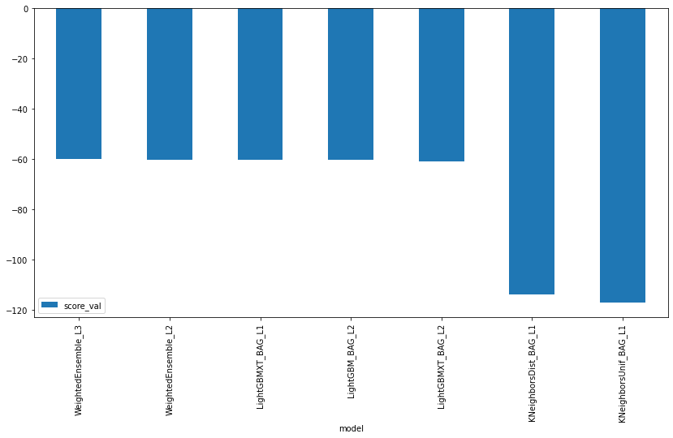

```python
leaderboard_new_df = pd.DataFrame(predictor_new_features.leaderboard())
leaderboard_new_df.plot(kind="bar", x="model", y="score_val", figsize=(14, 7))
plt.show()
```

```python
predictions_new_features = predictor_new_features.predict(test)
predictions_new_features.head()
```

```
0    25.509943
1    11.078977
2     9.098299
3     8.904437
4     8.784183
Name: count, dtype: float32
```

```python
predictions_new_features.describe()
predictions_new_features[predictions_new_features < 0] = 0
```

```python
submission_new_features = pd.read_csv("sampleSubmission.csv", parse_dates=["datetime"])
submission_new_features.head()
```

|  | datetime | count |
| --- | --- | --- |
| 0 | 2011-01-20 00:00:00 | 0 |
| 1 | 2011-01-20 01:00:00 | 0 |
| 2 | 2011-01-20 02:00:00 | 0 |
| 3 | 2011-01-20 03:00:00 | 0 |
| 4 | 2011-01-20 04:00:00 | 0 |

```python
submission_new_features["count"] = predictions_new_features
submission_new_features.to_csv("submission_new_features.csv", index=False)
```

```python
!kaggle competitions submit -c bike-sharing-demand -f submission_new_features.csv -m "Two new features (hours & Weekday)"
```

```
Successfully submitted to Bike Sharing Demand
```

```python
!kaggle competitions submissions -c bike-sharing-demand | tail -n +1 | head -n 6
```

```
fileName                     date                 description                                                                                         status    publicScore  privateScore
---------------------------  -------------------  --------------------------------------------------------------------------------------------------  --------  -----------  ------------
submission_new_features.csv  2023-06-01 14:43:01  Two new features (hours & Weekday)                                                                  complete  0.58036      0.58036
submission.csv               2023-06-01 14:39:34  Initial Submission                                                                                  complete  2.06263      2.06263
submission_new_hyp_3.csv     2023-06-01 07:29:37  new features with hyperparameters epoch, boost round, learning rate, extra trees, drop-out, leaves  complete  0.50079      0.50079
submission_new_hyp_2.csv     2023-06-01 07:29:35  new features with hyperparameters epoch, boost round, learning rate, extra trees                    complete  0.65221      0.65221
tail: write error: Broken pipe
```

#### New Score of 0.58036

## Step 6: Hyper parameter optimization

- There are many options for hyper parameter optimization.
- Options are to change the AutoGluon higher level parameters or the individual model hyperparameters.
- The hyperparameters of the models themselves that are in AutoGluon. Those need the `hyperparameter` and `hyperparameter_tune_kwargs` arguments.

```python
hyperparameters_1 = {
    "NN_TORCH": {
        "num_epochs": 100
    },
    "GBM": {
        "num_boost_round": 1000
    },
}
```

```python
hyperparameters_2 = {
    "NN_TORCH": {
        "num_epochs": 100,
        "learning_rate": 1e-5,
    },
    "GBM": {
        "num_boost_round": 1000,
        "extra_trees": True,
    },
}
```

```python
hyperparameters_3 = {
    "GBM": {"extra_trees": True, "num_boost_round": 1000, "num_leaves": 5},
    "NN_TORCH": {"num_epochs": 100, "learning_rate": 1e-5, "dropout_prob": 0.05},
}
```

```python
predictor_new_hp_1 = TabularPredictor(
    label="count",
    problem_type="regression",
    eval_metric="root_mean_squared_error",
    learner_kwargs={"ignored_columns": ["casual", "registered"]},
)

predictor_new_hp_1.fit(
    train_data=train,
    time_limit=120,
    presets="best_quality",
    hyperparameters=hyperparameters_1,
    refit_full="best",
)

predictor_new_hp_1.fit_summary()
```

```
No path specified. Models will be saved in: "AutogluonModels/ag-20230601_144303/"
Presets specified: ['best_quality']
Stack configuration (auto_stack=True): num_stack_levels=1, num_bag_folds=8, num_bag_sets=20
Beginning AutoGluon training ... Time limit = 120s
AutoGluon will save models to "AutogluonModels/ag-20230601_144303/"
AutoGluon Version:  0.7.0
Python Version:     3.8.10
Operating System:   Linux
Platform Machine:   x86_64
Platform Version:   #1 SMP Tue Apr 25 15:24:19 UTC 2023
Train Data Rows:    10886
Train Data Columns: 12
Label Column: count
Preprocessing data ...
Using Feature Generators to preprocess the data ...
Dropping user-specified ignored columns: ['casual', 'registered']
Fitting AutoMLPipelineFeatureGenerator...
	Available Memory:                    2552.53 MB
	Train Data (Original)  Memory Usage: 0.72 MB (0.0% of available memory)
	Inferring data type of each feature based on column values. Set feature_metadata_in to manually specify special dtypes of the features.
	Stage 1 Generators:
		Fitting AsTypeFeatureGenerator...
			Note: Converting 2 features to boolean dtype as they only contain 2 unique values.
	Stage 2 Generators:
		Fitting FillNaFeatureGenerator...
	Stage 3 Generators:
		Fitting IdentityFeatureGenerator...
		Fitting CategoryFeatureGenerator...
			Fitting CategoryMemoryMinimizeFeatureGenerator...
	Stage 4 Generators:
		Fitting DropUniqueFeatureGenerator...
	Types of features in original data (raw dtype, special dtypes):
		('category', []) : 2 | ['season', 'weather']
		('float', [])    : 3 | ['temp', 'atemp', 'windspeed']
		('int', [])      : 5 | ['holiday', 'workingday', 'humidity', 'hour', 'day']
	Types of features in processed data (raw dtype, special dtypes):
		('category', [])  : 2 | ['season', 'weather']
		('float', [])     : 3 | ['temp', 'atemp', 'windspeed']
		('int', [])       : 3 | ['humidity', 'hour', 'day']
		('int', ['bool']) : 2 | ['holiday', 'workingday']
```

[output cut: 41 more lines]

```
Automatically performing refit_full as a post-fit operation (due to `.fit(..., refit_full=True)`
Refitting models via `predictor.refit_full` using all of the data (combined train and validation)...
	Models trained in this way will have the suffix "_FULL" and have NaN validation score.
	This process is not bound by time_limit, but should take less time than the original `predictor.fit` call.
	To learn more, refer to the `.refit_full` method docstring which explains how "_FULL" models differ from normal models.
Fitting 1 L1 models ...
Fitting model: LightGBM_BAG_L1_FULL ...
	1.59s	 = Training   runtime
Fitting 1 L1 models ...
Fitting model: NeuralNetTorch_BAG_L1_FULL ...
	6.85s	 = Training   runtime
Fitting model: WeightedEnsemble_L2_FULL | Skipping fit via cloning parent ...
	0.17s	 = Training   runtime
Refit complete, total runtime = 10.5s
TabularPredictor saved. To load, use: predictor = TabularPredictor.load("AutogluonModels/ag-20230601_144303/")
```

```
*** Summary of fit() ***
Estimated performance of each model:
                        model  score_val  pred_time_val    fit_time  pred_time_val_marginal  fit_time_marginal  stack_level  can_infer  fit_order
0         WeightedEnsemble_L2 -61.513434       1.707213   81.267027                0.000782           0.166178            2       True          3
1             LightGBM_BAG_L1 -61.564474       1.525321   20.440489                1.525321          20.440489            1       True          1
2         WeightedEnsemble_L3 -62.909433       2.188551  123.195870                0.000821           0.168333            3       True          6
3             LightGBM_BAG_L2 -63.311743       1.793295   95.779210                0.086864          14.678361            2       True          4
4       NeuralNetTorch_BAG_L2 -65.489339       2.100866  108.349176                0.394434          27.248328            2       True          5
5       NeuralNetTorch_BAG_L1 -86.110372       0.181111   60.660360                0.181111          60.660360            1       True          2
6    WeightedEnsemble_L2_FULL        NaN            NaN    8.604759                     NaN           0.166178            2       True          9
7  NeuralNetTorch_BAG_L1_FULL        NaN            NaN    6.851289                     NaN           6.851289            1       True          8
8        LightGBM_BAG_L1_FULL        NaN            NaN    1.587292                     NaN           1.587292            1       True          7
Number of models trained: 9
Types of models trained:
{'StackerEnsembleModel_TabularNeuralNetTorch', 'StackerEnsembleModel_LGB', 'WeightedEnsembleModel'}
Bagging used: True  (with 8 folds)
Multi-layer stack-ensembling used: True  (with 3 levels)
Feature Metadata (Processed):
(raw dtype, special dtypes):
('category', [])  : 2 | ['season', 'weather']
('float', [])     : 3 | ['temp', 'atemp', 'windspeed']
('int', [])       : 3 | ['humidity', 'hour', 'day']
('int', ['bool']) : 2 | ['holiday', 'workingday']
Plot summary of models saved to file: AutogluonModels/ag-20230601_144303/SummaryOfModels.html
*** End of fit() summary ***
```

[output not shown]

[output cut: 61 more lines]

```
 5                0.181111          60.660360            1       True
 6                     NaN           0.166178            2       True
 7                     NaN           6.851289            1       True
 8                     NaN           1.587292            1       True

    fit_order
 0          3
 1          1
 2          6
 3          4
 4          5
 5          2
 6          9
 7          8
 8          7  }
```

```python
predictor_new_hp_2 = TabularPredictor(
    label="count",
    problem_type="regression",
    eval_metric="root_mean_squared_error",
    learner_kwargs={"ignored_columns": ["casual", "registered"]},
)

predictor_new_hp_2.fit(
    train_data=train,
    time_limit=120,
    presets="best_quality",
    hyperparameters=hyperparameters_2,
    refit_full="best",
)

predictor_new_hp_2.fit_summary()
```

```
No path specified. Models will be saved in: "AutogluonModels/ag-20230601_144532/"
Presets specified: ['best_quality']
Stack configuration (auto_stack=True): num_stack_levels=1, num_bag_folds=8, num_bag_sets=20
Beginning AutoGluon training ... Time limit = 120s
AutoGluon will save models to "AutogluonModels/ag-20230601_144532/"
AutoGluon Version:  0.7.0
Python Version:     3.8.10
Operating System:   Linux
Platform Machine:   x86_64
Platform Version:   #1 SMP Tue Apr 25 15:24:19 UTC 2023
Train Data Rows:    10886
Train Data Columns: 12
Label Column: count
Preprocessing data ...
Using Feature Generators to preprocess the data ...
Dropping user-specified ignored columns: ['casual', 'registered']
Fitting AutoMLPipelineFeatureGenerator...
	Available Memory:                    2555.8 MB
	Train Data (Original)  Memory Usage: 0.72 MB (0.0% of available memory)
	Inferring data type of each feature based on column values. Set feature_metadata_in to manually specify special dtypes of the features.
	Stage 1 Generators:
		Fitting AsTypeFeatureGenerator...
			Note: Converting 2 features to boolean dtype as they only contain 2 unique values.
	Stage 2 Generators:
		Fitting FillNaFeatureGenerator...
	Stage 3 Generators:
		Fitting IdentityFeatureGenerator...
		Fitting CategoryFeatureGenerator...
			Fitting CategoryMemoryMinimizeFeatureGenerator...
	Stage 4 Generators:
		Fitting DropUniqueFeatureGenerator...
	Types of features in original data (raw dtype, special dtypes):
		('category', []) : 2 | ['season', 'weather']
		('float', [])    : 3 | ['temp', 'atemp', 'windspeed']
		('int', [])      : 5 | ['holiday', 'workingday', 'humidity', 'hour', 'day']
	Types of features in processed data (raw dtype, special dtypes):
		('category', [])  : 2 | ['season', 'weather']
		('float', [])     : 3 | ['temp', 'atemp', 'windspeed']
		('int', [])       : 3 | ['humidity', 'hour', 'day']
		('int', ['bool']) : 2 | ['holiday', 'workingday']
```

[output cut: 36 more lines]

```
Fitting model: WeightedEnsemble_L3 ... Training model for up to 119.9s of the -19.08s of remaining time.
	-64.04	 = Validation score   (-root_mean_squared_error)
	0.17s	 = Training   runtime
	0.0s	 = Validation runtime
AutoGluon training complete, total runtime = 139.43s ... Best model: "WeightedEnsemble_L2"
Automatically performing refit_full as a post-fit operation (due to `.fit(..., refit_full=True)`
Refitting models via `predictor.refit_full` using all of the data (combined train and validation)...
	Models trained in this way will have the suffix "_FULL" and have NaN validation score.
	This process is not bound by time_limit, but should take less time than the original `predictor.fit` call.
	To learn more, refer to the `.refit_full` method docstring which explains how "_FULL" models differ from normal models.
Fitting 1 L1 models ...
Fitting model: LightGBM_BAG_L1_FULL ...
	1.54s	 = Training   runtime
Refit complete, total runtime = 3.95s
TabularPredictor saved. To load, use: predictor = TabularPredictor.load("AutogluonModels/ag-20230601_144532/")
```

```
*** Summary of fit() ***
Estimated performance of each model:
                   model   score_val  pred_time_val    fit_time  pred_time_val_marginal  fit_time_marginal  stack_level  can_infer  fit_order
0        LightGBM_BAG_L1  -63.345619       2.101660   21.840686                2.101660          21.840686            1       True          1
1    WeightedEnsemble_L2  -63.345619       2.102354   22.002602                0.000694           0.161916            2       True          3
2        LightGBM_BAG_L2  -64.039953       3.039567  100.124812                0.795607          18.140151            2       True          4
3    WeightedEnsemble_L3  -64.039953       3.040397  100.289885                0.000830           0.165072            3       True          6
4  NeuralNetTorch_BAG_L1 -148.020895       0.142299   60.143975                0.142299          60.143975            1       True          2
5  NeuralNetTorch_BAG_L2 -320.070707       2.388217  105.632385                0.144257          23.647723            2       True          5
6   LightGBM_BAG_L1_FULL         NaN            NaN    1.541076                     NaN           1.541076            1       True          7
Number of models trained: 7
Types of models trained:
{'StackerEnsembleModel_TabularNeuralNetTorch', 'StackerEnsembleModel_LGB', 'WeightedEnsembleModel'}
Bagging used: True  (with 8 folds)
Multi-layer stack-ensembling used: True  (with 3 levels)
Feature Metadata (Processed):
(raw dtype, special dtypes):
('category', [])  : 2 | ['season', 'weather']
('float', [])     : 3 | ['temp', 'atemp', 'windspeed']
('int', [])       : 3 | ['humidity', 'hour', 'day']
('int', ['bool']) : 2 | ['holiday', 'workingday']
Plot summary of models saved to file: AutogluonModels/ag-20230601_144532/SummaryOfModels.html
*** End of fit() summary ***
```

[output not shown]

[output cut: 37 more lines]

```
 1                0.000694           0.161916            2       True
 2                0.795607          18.140151            2       True
 3                0.000830           0.165072            3       True
 4                0.142299          60.143975            1       True
 5                0.144257          23.647723            2       True
 6                     NaN           1.541076            1       True

    fit_order
 0          1
 1          3
 2          4
 3          6
 4          2
 5          5
 6          7  }
```

```python
predictor_new_hp_3 = TabularPredictor(
    label="count",
    problem_type="regression",
    eval_metric="root_mean_squared_error",
    learner_kwargs={"ignored_columns": ["casual", "registered"]},
)

predictor_new_hp_3.fit(
    train_data=train,
    time_limit=120,
    presets="best_quality",
    hyperparameters=hyperparameters_3,
    refit_full="best",
)

predictor_new_hp_3.fit_summary()
```

```
No path specified. Models will be saved in: "AutogluonModels/ag-20230601_144755/"
Presets specified: ['best_quality']
Stack configuration (auto_stack=True): num_stack_levels=1, num_bag_folds=8, num_bag_sets=20
Beginning AutoGluon training ... Time limit = 120s
AutoGluon will save models to "AutogluonModels/ag-20230601_144755/"
AutoGluon Version:  0.7.0
Python Version:     3.8.10
Operating System:   Linux
Platform Machine:   x86_64
Platform Version:   #1 SMP Tue Apr 25 15:24:19 UTC 2023
Train Data Rows:    10886
Train Data Columns: 12
Label Column: count
Preprocessing data ...
Using Feature Generators to preprocess the data ...
Dropping user-specified ignored columns: ['casual', 'registered']
Fitting AutoMLPipelineFeatureGenerator...
	Available Memory:                    2547.57 MB
	Train Data (Original)  Memory Usage: 0.72 MB (0.0% of available memory)
	Inferring data type of each feature based on column values. Set feature_metadata_in to manually specify special dtypes of the features.
	Stage 1 Generators:
		Fitting AsTypeFeatureGenerator...
			Note: Converting 2 features to boolean dtype as they only contain 2 unique values.
	Stage 2 Generators:
		Fitting FillNaFeatureGenerator...
	Stage 3 Generators:
		Fitting IdentityFeatureGenerator...
		Fitting CategoryFeatureGenerator...
			Fitting CategoryMemoryMinimizeFeatureGenerator...
	Stage 4 Generators:
		Fitting DropUniqueFeatureGenerator...
	Types of features in original data (raw dtype, special dtypes):
		('category', []) : 2 | ['season', 'weather']
		('float', [])    : 3 | ['temp', 'atemp', 'windspeed']
		('int', [])      : 5 | ['holiday', 'workingday', 'humidity', 'hour', 'day']
	Types of features in processed data (raw dtype, special dtypes):
		('category', [])  : 2 | ['season', 'weather']
		('float', [])     : 3 | ['temp', 'atemp', 'windspeed']
		('int', [])       : 3 | ['humidity', 'hour', 'day']
		('int', ['bool']) : 2 | ['holiday', 'workingday']
```

[output cut: 42 more lines]

```
Refitting models via `predictor.refit_full` using all of the data (combined train and validation)...
	Models trained in this way will have the suffix "_FULL" and have NaN validation score.
	This process is not bound by time_limit, but should take less time than the original `predictor.fit` call.
	To learn more, refer to the `.refit_full` method docstring which explains how "_FULL" models differ from normal models.
Fitting 1 L1 models ...
Fitting model: LightGBM_BAG_L1_FULL ...
	0.6s	 = Training   runtime
Fitting 1 L1 models ...
Fitting model: NeuralNetTorch_BAG_L1_FULL ...
	7.8s	 = Training   runtime
Fitting 1 L2 models ...
Fitting model: LightGBM_BAG_L2_FULL ...
	0.6s	 = Training   runtime
Refit complete, total runtime = 10.88s
TabularPredictor saved. To load, use: predictor = TabularPredictor.load("AutogluonModels/ag-20230601_144755/")
```

```
*** Summary of fit() ***
Estimated performance of each model:
                        model   score_val  pred_time_val    fit_time  pred_time_val_marginal  fit_time_marginal  stack_level  can_infer  fit_order
0             LightGBM_BAG_L2  -68.559370       2.007048   96.484189                0.763687          15.727599            2       True          4
1         WeightedEnsemble_L3  -68.559370       2.007807   96.651094                0.000760           0.166905            3       True          6
2             LightGBM_BAG_L1  -72.988425       0.868441   15.433599                0.868441          15.433599            1       True          1
3         WeightedEnsemble_L2  -72.988425       0.869536   15.625655                0.001095           0.192056            2       True          3
4       NeuralNetTorch_BAG_L1 -147.026409       0.374919   65.322992                0.374919          65.322992            1       True          2
5       NeuralNetTorch_BAG_L2 -275.585425       1.372813  107.470856                0.129453          26.714266            2       True          5
6  NeuralNetTorch_BAG_L1_FULL         NaN            NaN    7.803822                     NaN           7.803822            1       True          8
7        LightGBM_BAG_L2_FULL         NaN            NaN    9.006895                     NaN           0.599314            2       True          9
8        LightGBM_BAG_L1_FULL         NaN            NaN    0.603759                     NaN           0.603759            1       True          7
Number of models trained: 9
Types of models trained:
{'StackerEnsembleModel_TabularNeuralNetTorch', 'StackerEnsembleModel_LGB', 'WeightedEnsembleModel'}
Bagging used: True  (with 8 folds)
Multi-layer stack-ensembling used: True  (with 3 levels)
Feature Metadata (Processed):
(raw dtype, special dtypes):
('category', [])  : 2 | ['season', 'weather']
('float', [])     : 3 | ['temp', 'atemp', 'windspeed']
('int', [])       : 3 | ['humidity', 'hour', 'day']
('int', ['bool']) : 2 | ['holiday', 'workingday']
Plot summary of models saved to file: AutogluonModels/ag-20230601_144755/SummaryOfModels.html
*** End of fit() summary ***
```

[output not shown]

[output cut: 61 more lines]

```
 5                0.129453          26.714266            2       True
 6                     NaN           7.803822            1       True
 7                     NaN           0.599314            2       True
 8                     NaN           0.603759            1       True

    fit_order
 0          4
 1          6
 2          1
 3          3
 4          2
 5          5
 6          8
 7          9
 8          7  }
```

```python
# Leaderboard dataframe
leaderboard_new_hp_df_1 = pd.DataFrame(predictor_new_hp_1.leaderboard(silent=True))
leaderboard_new_hp_df_1
```

|  | model | score_val | pred_time_val | fit_time | pred_time_val_marginal | fit_time_marginal | stack_level | can_infer | fit_order |
| --- | --- | --- | --- | --- | --- | --- | --- | --- | --- |
| 0 | WeightedEnsemble_L2 | -61.513434 | 1.707213 | 81.267027 | 0.000782 | 0.166178 | 2 | True | 3 |
| 1 | LightGBM_BAG_L1 | -61.564474 | 1.525321 | 20.440489 | 1.525321 | 20.440489 | 1 | True | 1 |
| 2 | WeightedEnsemble_L3 | -62.909433 | 2.188551 | 123.195870 | 0.000821 | 0.168333 | 3 | True | 6 |
| 3 | LightGBM_BAG_L2 | -63.311743 | 1.793295 | 95.779210 | 0.086864 | 14.678361 | 2 | True | 4 |
| 4 | NeuralNetTorch_BAG_L2 | -65.489339 | 2.100866 | 108.349176 | 0.394434 | 27.248328 | 2 | True | 5 |
| 5 | NeuralNetTorch_BAG_L1 | -86.110372 | 0.181111 | 60.660360 | 0.181111 | 60.660360 | 1 | True | 2 |
| 6 | WeightedEnsemble_L2_FULL | NaN | NaN | 8.604759 | NaN | 0.166178 | 2 | True | 9 |
| 7 | NeuralNetTorch_BAG_L1_FULL | NaN | NaN | 6.851289 | NaN | 6.851289 | 1 | True | 8 |
| 8 | LightGBM_BAG_L1_FULL | NaN | NaN | 1.587292 | NaN | 1.587292 | 1 | True | 7 |

```python
# Leaderboard dataframe
leaderboard_new_hp_df_2 = pd.DataFrame(predictor_new_hp_2.leaderboard(silent=True))
leaderboard_new_hp_df_2
```

|  | model | score_val | pred_time_val | fit_time | pred_time_val_marginal | fit_time_marginal | stack_level | can_infer | fit_order |
| --- | --- | --- | --- | --- | --- | --- | --- | --- | --- |
| 0 | LightGBM_BAG_L1 | -63.345619 | 2.101660 | 21.840686 | 2.101660 | 21.840686 | 1 | True | 1 |
| 1 | WeightedEnsemble_L2 | -63.345619 | 2.102354 | 22.002602 | 0.000694 | 0.161916 | 2 | True | 3 |
| 2 | LightGBM_BAG_L2 | -64.039953 | 3.039567 | 100.124812 | 0.795607 | 18.140151 | 2 | True | 4 |
| 3 | WeightedEnsemble_L3 | -64.039953 | 3.040397 | 100.289885 | 0.000830 | 0.165072 | 3 | True | 6 |
| 4 | NeuralNetTorch_BAG_L1 | -148.020895 | 0.142299 | 60.143975 | 0.142299 | 60.143975 | 1 | True | 2 |
| 5 | NeuralNetTorch_BAG_L2 | -320.070707 | 2.388217 | 105.632385 | 0.144257 | 23.647723 | 2 | True | 5 |
| 6 | LightGBM_BAG_L1_FULL | NaN | NaN | 1.541076 | NaN | 1.541076 | 1 | True | 7 |

```python
# Leaderboard dataframe
leaderboard_new_hp_df_3 = pd.DataFrame(predictor_new_hp_3.leaderboard(silent=True))
leaderboard_new_hp_df_3
```

|  | model | score_val | pred_time_val | fit_time | pred_time_val_marginal | fit_time_marginal | stack_level | can_infer | fit_order |
| --- | --- | --- | --- | --- | --- | --- | --- | --- | --- |
| 0 | LightGBM_BAG_L2 | -68.559370 | 2.007048 | 96.484189 | 0.763687 | 15.727599 | 2 | True | 4 |
| 1 | WeightedEnsemble_L3 | -68.559370 | 2.007807 | 96.651094 | 0.000760 | 0.166905 | 3 | True | 6 |
| 2 | LightGBM_BAG_L1 | -72.988425 | 0.868441 | 15.433599 | 0.868441 | 15.433599 | 1 | True | 1 |
| 3 | WeightedEnsemble_L2 | -72.988425 | 0.869536 | 15.625655 | 0.001095 | 0.192056 | 2 | True | 3 |
| 4 | NeuralNetTorch_BAG_L1 | -147.026409 | 0.374919 | 65.322992 | 0.374919 | 65.322992 | 1 | True | 2 |
| 5 | NeuralNetTorch_BAG_L2 | -275.585425 | 1.372813 | 107.470856 | 0.129453 | 26.714266 | 2 | True | 5 |
| 6 | NeuralNetTorch_BAG_L1_FULL | NaN | NaN | 7.803822 | NaN | 7.803822 | 1 | True | 8 |
| 7 | LightGBM_BAG_L2_FULL | NaN | NaN | 9.006895 | NaN | 0.599314 | 2 | True | 9 |
| 8 | LightGBM_BAG_L1_FULL | NaN | NaN | 0.603759 | NaN | 0.603759 | 1 | True | 7 |

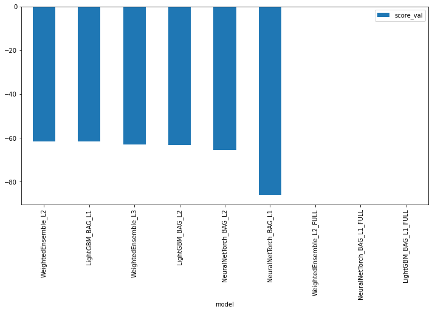

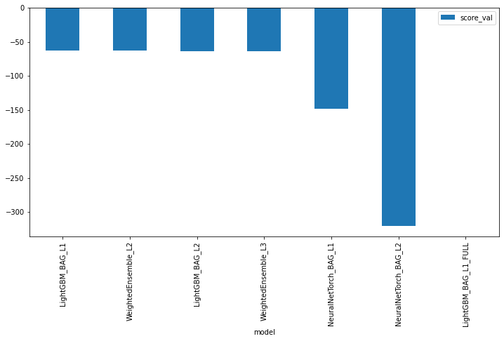

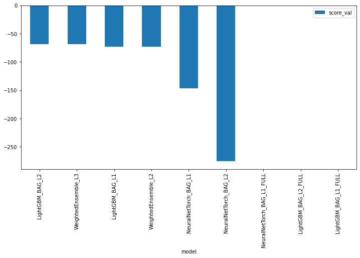

```python
leaderboard_new_hp_df_1.plot(kind="bar", x="model", y="score_val", figsize=(12, 6))
leaderboard_new_hp_df_2.plot(kind="bar", x="model", y="score_val", figsize=(12, 6))
leaderboard_new_hp_df_3.plot(kind="bar", x="model", y="score_val", figsize=(12, 6))
plt.show()
```

```python
predictions_new_hyp_1 = predictor_new_hp_1.predict(test)
predictions_new_hyp_1.head()
```

```
0    21.584213
1     4.534583
2     0.507605
3     1.623464
4     1.280358
Name: count, dtype: float32
```

```python
predictions_new_hyp_2 = predictor_new_hp_2.predict(test)
predictions_new_hyp_2.head()
```

```
0    29.971573
1     8.629538
2     4.112672
3    -1.318882
4    -1.364102
Name: count, dtype: float32
```

```python
predictions_new_hyp_3 = predictor_new_hp_3.predict(test)
predictions_new_hyp_3.head()
```

```
0    24.633934
1     8.686478
2     8.407059
3     8.726441
4     8.746774
Name: count, dtype: float32
```

```python
predictions_new_hyp_1[predictions_new_hyp_1<0] = 0
predictions_new_hyp_2[predictions_new_hyp_2<0] = 0
predictions_new_hyp_3[predictions_new_hyp_3<0] = 0
```

```python
submission_new_hyp_1 = pd.read_csv("sampleSubmission.csv", parse_dates=["datetime"])
submission_new_hyp_1["count"] = predictions_new_hyp_1
submission_new_hyp_1.to_csv("submission_new_hyp_1.csv", index=False)

submission_new_hyp_2 = pd.read_csv("sampleSubmission.csv", parse_dates=["datetime"])
submission_new_hyp_2["count"] = predictions_new_hyp_2
submission_new_hyp_2.to_csv("submission_new_hyp_2.csv", index=False)

submission_new_hyp_3 = pd.read_csv("sampleSubmission.csv", parse_dates=["datetime"])
submission_new_hyp_3["count"] = predictions_new_hyp_3
submission_new_hyp_3.to_csv("submission_new_hyp_3.csv", index=False)
```

```python
!kaggle competitions submit -c bike-sharing-demand -f submission_new_hyp_1.csv -m "new features with hyperparameters epoch, boost round"
!kaggle competitions submit -c bike-sharing-demand -f submission_new_hyp_2.csv -m "new features with hyperparameters epoch, boost round, learning rate, extra trees"
!kaggle competitions submit -c bike-sharing-demand -f submission_new_hyp_3.csv -m "new features with hyperparameters epoch, boost round, learning rate, extra trees, drop-out, leaves"
```

```
Successfully submitted to Bike Sharing Demand
```

```python
!kaggle competitions submissions -c bike-sharing-demand | tail -n +1 | head -n 6
```

```
fileName                     date                 description                                                                                         status    publicScore  privateScore
---------------------------  -------------------  --------------------------------------------------------------------------------------------------  --------  -----------  ------------
submission_new_hyp_3.csv     2023-06-01 14:50:49  new features with hyperparameters epoch, boost round, learning rate, extra trees, drop-out, leaves  pending
submission_new_hyp_2.csv     2023-06-01 14:50:46  new features with hyperparameters epoch, boost round, learning rate, extra trees                    pending
submission_new_hyp_1.csv     2023-06-01 14:50:44  new features with hyperparameters epoch, boost round                                                complete  0.60783      0.60783
submission_new_features.csv  2023-06-01 14:43:01  Two new features (hours & Weekday)                                                                  complete  0.58036      0.58036
tail: write error: Broken pipe
```